# Revolut_notebook

```python
import warnings
warnings.filterwarnings('ignore')

import os
import sys
sys.path.append(os.path.abspath("./code/"))

from config import engine
from data_preparation import Data
import lightgbm
from lightgbm import LGBMClassifier
import matplotlib.pyplot as plt
import numpy as np

import pandas as pd
import pandas_profiling
import seaborn as sns
from sklearn.calibration import calibration_curve
from sklearn.metrics import precision_score, recall_score, confusion_matrix, roc_curve, auc
from training import Train
from utils import get_data
```

### A quick look at the data

```python
training_data = get_data('training_data', engine)
training_data.head()
```

|  | CURRENCY | TRANSACTION_STATE | TRANSACTION_DATE | MERCHANT_COUNTRY | ENTRY_METHOD | USER_ID | TYPE | SOURCE | AMOUNT_USD | HAS_EMAIL | ... | COUNTRY | BIRTH_YEAR | KYC | FAILED_SIGN_IN_ATTEMPTS | CURRENCIES_USED | MERCH_COUNTRIES_USED | TIME_SINCE_LAST_TRANSACTION | COUNT | ROLLING_AVG | ROLLING_SUM |
| --- | --- | --- | --- | --- | --- | --- | --- | --- | --- | --- | --- | --- | --- | --- | --- | --- | --- | --- | --- | --- | --- |
| 0 | DKK | REVERTED | 1100.318753 | 0 | misc | 000e88bb-d302-4fdc-b757-2b1a2c33e7d6 | TOPUP | HERA | 14 | 1.0 | ... | DK | 1989.0 | PASSED | 0.0 | 1 | 2.0 | 0.0 | 1 | 14.00 | 14.0 |
| 1 | DKK | COMPLETED | 1100.318955 | 0 | misc | 000e88bb-d302-4fdc-b757-2b1a2c33e7d6 | TOPUP | HERA | 1490 | 1.0 | ... | DK | 1989.0 | PASSED | 0.0 | 1 | 2.0 | 0.0 | 2 | 752.00 | 1504.0 |
| 2 | DKK | COMPLETED | 1143.990318 | 0 | misc | 000e88bb-d302-4fdc-b757-2b1a2c33e7d6 | TOPUP | HERA | 7451 | 1.0 | ... | DK | 1989.0 | PASSED | 0.0 | 1 | 2.0 | 62886.0 | 3 | 2985.00 | 8955.0 |
| 3 | DKK | COMPLETED | 1143.994202 | 0 | misc | 000e88bb-d302-4fdc-b757-2b1a2c33e7d6 | BANK_TRANSFER | CRONUS | 8880 | 1.0 | ... | DK | 1989.0 | PASSED | 0.0 | 1 | 2.0 | 5.0 | 4 | 4458.75 | 17835.0 |
| 4 | DKK | COMPLETED | 1156.239779 | 0 | misc | 000e88bb-d302-4fdc-b757-2b1a2c33e7d6 | TOPUP | HERA | 7451 | 1.0 | ... | DK | 1989.0 | PASSED | 0.0 | 1 | 2.0 | 17633.0 | 5 | 5057.20 | 25286.0 |

5 rows × 24 columns

```python
# Load the data
t = Train("data/training_data.csv")
unlabeled_X, orig_Xtrain, orig_Xtest, orig_ytrain, orig_ytest, test_idx = t.prepare_data_for_training()
undersampled_df, undersampled_y_train = t.balance_training_dataset(orig_Xtrain, orig_ytrain)
```

# Predicting Fraud

```
Number and percent of fraudsters in the dataset:
True: 7724, 96.3%
Fraudster: 297, 3.7%

Number and percent of transcations in the dataset:
True: 624828, 97.82%
Fraudster: 13914, 2.18%
```

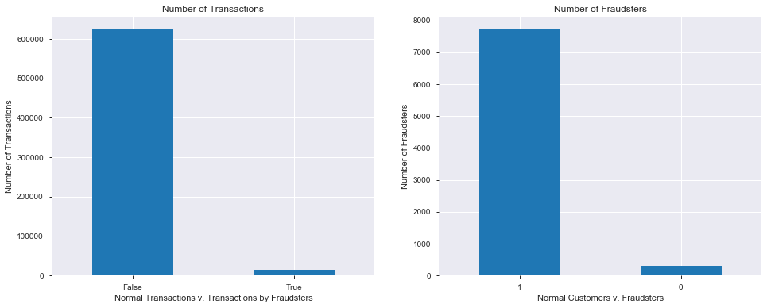

```python
# Fraudster proportions
num_fraudsters = len(set(training_data['USER_ID'][training_data['IS_FRAUDSTER'] == True]))
total = len(set((training_data['USER_ID'])))
normal_num = total - num_fraudsters

# Transaction proportions
y = training_data['IS_FRAUDSTER']
num_points = training_data['IS_FRAUDSTER'].value_counts().sum()
print("Number and percent of fraudsters in the dataset:")
print('True: ' + str(normal_num) + ", " + str(round(normal_num / total * 100, 2)) + '%')
print('Fraudster: ' + str(num_fraudsters) + ", " + str(round(num_fraudsters / total * 100, 2)) + '%')
print()
print("Number and percent of transcations in the dataset:")
print('True: ' + str(y.value_counts()[0]) + ", " + str(round(y.value_counts()[0] / num_points * 100, 2)) + '%')
print('Fraudster: ' + str(y.value_counts()[1]) + ", " + str(round(y.value_counts()[1] / num_points * 100, 2)) + '%')
fig, axes = plt.subplots(1, 2, figsize = (16, 6))

# Vizualization
pd.Series([num_fraudsters, normal_num]).plot(kind='bar', rot=0, ax=axes[1], title='Number of Fraudsters')
axes[1].set_ylabel('Number of Fraudsters')
axes[1].set_xlabel("Normal Customers v. Fraudsters")
axes[1].invert_xaxis()
y.value_counts().plot(kind='bar', ax=axes[0], rot=0, title='Number of Transactions')
axes[0].set_ylabel('Number of Transactions')
axes[0].set_xlabel("Normal Transactions v. Transactions by Fraudsters");
```

This is considered a severe class imbalance, as only 1 in 30 known users are fraudsters.

```python
num_users_in_transactions_but_not_users = len(unlabeled_X)
num_transactions_by_users_not_in_users_table = sum(training_data['IS_FRAUDSTER'].isna())
print("Looking more deeply at the data, there are", num_users_in_transactions_but_not_users, "who made", num_transactions_by_users_not_in_users_table, "transactions that we do not know if are fraudulent or not.")
print()
print("By the end of this presentation, we will be able to determine with confidence, whether or not they are.")
```

```
Looking more deeply at the data, there are 49909 who made 49909 transactions that we do not know if are fraudulent or not.

By the end of this presentation, we will be able to determine with confidence, whether or not they are.
```

### Observations about Features:

```
- STATE in the Users table (ACTIVE, PENDING, or LOCKED) is highly correlated with fraudster. This seems like a feature determined retroactively and could be data leakage, so it would be best not to use it.

- The third most common transaction amount is zero dollars. I wonder why?
```

### More EDA

Interesting plots on the demographics and habits of fraudsters including birth year, country where transactions occurred, verification status, amount of time since last transaction, and number of failed sign-in attempts.

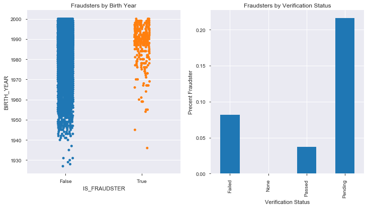

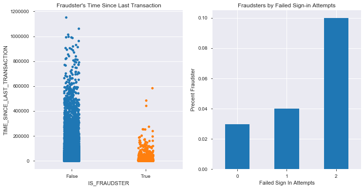

```python
all_users = pd.read_csv("data/users.csv")
fig, ax = plt.subplots(nrows=1, ncols=2, figsize=(12,6))
sns.stripplot('IS_FRAUDSTER', 'BIRTH_YEAR', data=all_users, ax=ax[0])
ax[0].set_title("Fraudsters by Birth Year")
ax[1] = all_users[['KYC', 'IS_FRAUDSTER']].groupby(['KYC']).mean().unstack().plot.bar()
ax[1].set_xlabel("Verification Status")
ax[1].set_ylabel("Precent Fraudster")
ax[1].set_xticklabels(['Failed','None', 'Passed', 'Pending'])
ax[1].set_title("Fraudsters by Verification Status")

fig, ax = plt.subplots(nrows=1, ncols=2, figsize=(12,6))
sns.stripplot(x="IS_FRAUDSTER", y="TIME_SINCE_LAST_TRANSACTION", data=training_data, ax=ax[0], jitter=True)
ax[0].set_title("Fraudster's Time Since Last Transaction")
grpby = all_users[['FAILED_SIGN_IN_ATTEMPTS', 'IS_FRAUDSTER']].groupby(['FAILED_SIGN_IN_ATTEMPTS']).mean().unstack()
ax[1] = grpby.loc[:, grpby['IS_FRAUDSTER'] > 0].plot.bar();
ax[1].set_xlabel("Failed Sign In Attempts")
ax[1].set_ylabel("Precent Fraudster")
ax[1].set_xticklabels(['0','1', '2', '3', '6'], rotation='horizontal')
ax[1].set_title("Fraudsters by Failed Sign-in Attempts");
```

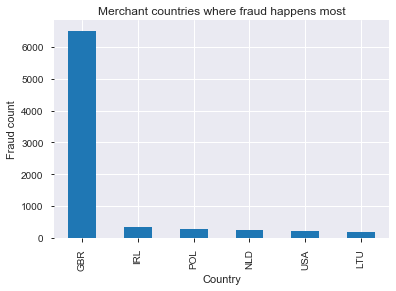

```python
training_data[training_data['IS_FRAUDSTER']== True]['MERCHANT_COUNTRY'][training_data['MERCHANT_COUNTRY'] != '0'].value_counts()[:6].plot.bar()
plt.title('Merchant countries where fraud happens most')
plt.xlabel("Country")
plt.ylabel("Fraud count");
```

It's not so surprising that the largest number of frauds happened in GBR given Revolut's location, but I was surprised to see Lithuania on the leaderboard.

Below, we see that true customers use more currencies than fraudsters, to my surprise.

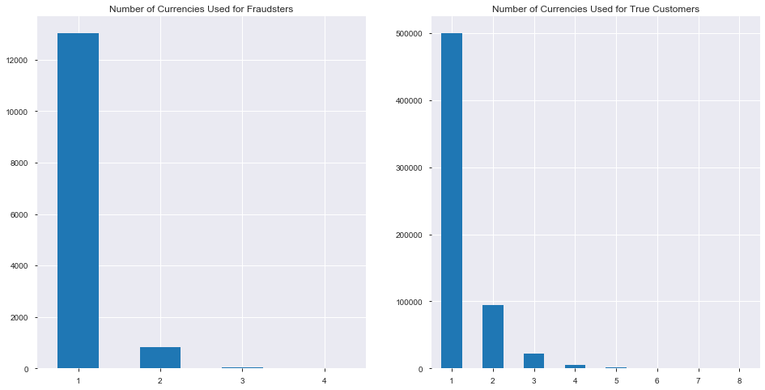

```python
fig, axes = plt.subplots(nrows=1, ncols=2, figsize=(16,8))
training_data['CURRENCIES_USED'][training_data['IS_FRAUDSTER']==True].value_counts().plot(kind='bar', ax=axes[0], rot=0, title='Number of Currencies Used for Fraudsters')
training_data['CURRENCIES_USED'][training_data['IS_FRAUDSTER']==False].value_counts().sort_index().plot(kind='bar', ax=axes[1], rot=0, title='Number of Currencies Used for True Customers');
```

Here we see the number of merchant countries used by fraudsters and I was suprised again to find that there were fewer. I guess they do less traveling than the average Revolut customer!

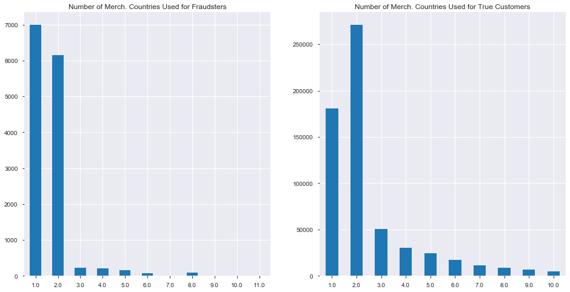

```python
fig, axes = plt.subplots(nrows=1, ncols=2, figsize=(16,8))
training_data['MERCH_COUNTRIES_USED'][training_data['IS_FRAUDSTER']==True].value_counts().sort_index().plot(kind='bar', ax=axes[0], rot=0, title='Number of Merch. Countries Used for Fraudsters')
training_data['MERCH_COUNTRIES_USED'][training_data['IS_FRAUDSTER']==False].value_counts()[:10].sort_index().plot(kind='bar', ax=axes[1], rot=0, title='Number of Merch. Countries Used for True Customers');
```

My goal for this project will be to identify whether or not the unknown actions are or are not fraudulent.

# Cleaning

- [x] Put transaction and sign up dates in datetime format
- [x] Convert IS_FRAUDSTER to boolean type
- [x] Entry method should be NaN if not using credit card
- [X] One-hot encode categorical values
- Features to remove:
  - [X] AMOUNT, multicollinear with AMOUNT_USD
  - [x] MERCHANT_COUNTRY, there are an enormous amount and it is most null values
  - [x] USER_ID, would explode the feature space / dimensionality of the model
    - Instead, let's create features to describe the user
      - [X] ROLLING_SUM, ROLLING_AVG, COUNT of transactions and also number of currencies/countries used

# Feature Engineering

- [x] Transaction count
  - I would guess that it is likely fraud will occur on first transaction by user.
- [x] How long since last transaction?
  - I would guess that fraudulent transactions happen immediately after a 'test' purchase.
- [X] How many currencies has this user transacted from?
- [X] How many countries?
- [X] Were the country and currency the same as the last transaction?
- Other features:
  - [x] Total AMOUNT_USD (ROLLING_SUM)
  - [x] Avg. AMOUNT_USD (ROLLING_AVG)
  - [x] Total number of transactions (COUNT)

# Modeling

### Undersampling

Let's first balance the transactions data by randomly undersampling the majority class and then look at the correlations of the features.

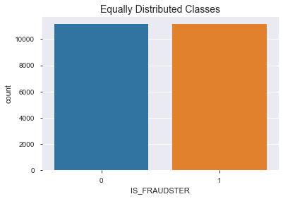

```python
sns.countplot(undersampled_y_train)
plt.title('Equally Distributed Classes', fontsize=14)
plt.show();
```

Much better!

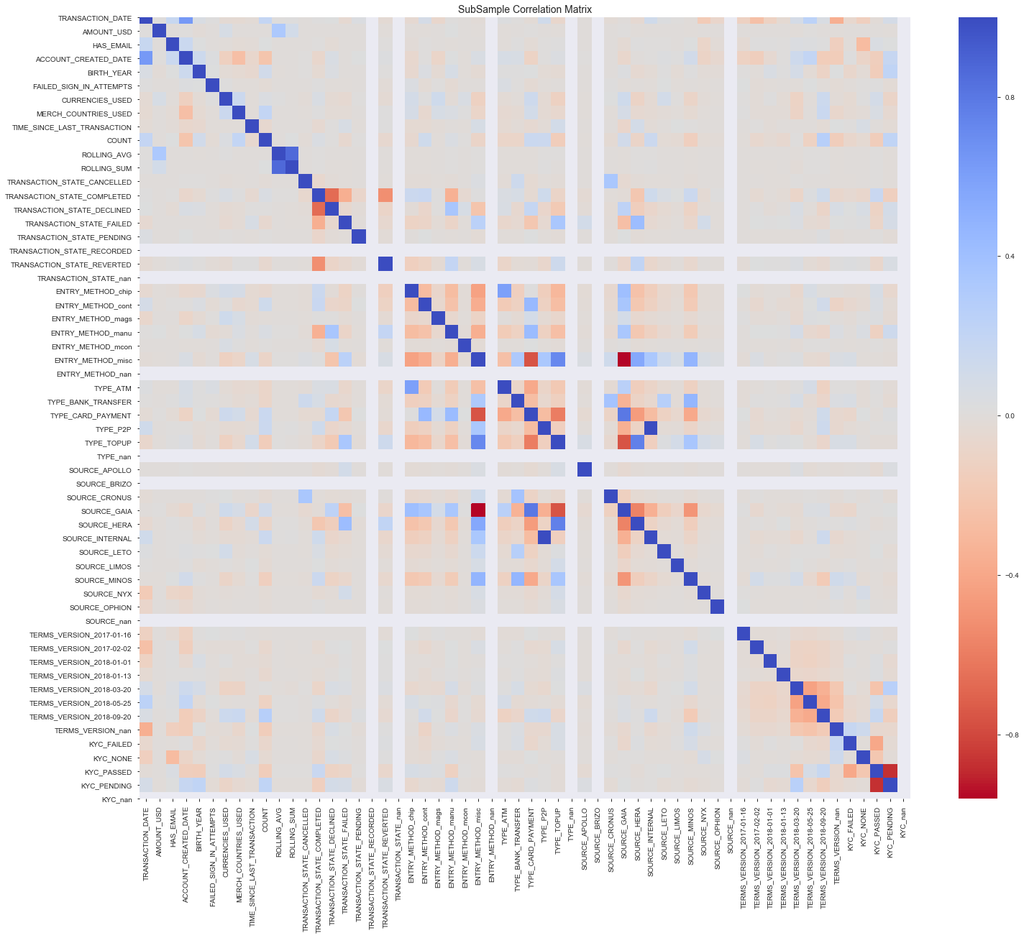

```python
col_list = [i for i in list(undersampled_df.columns) if (('CURRENCY') not in i) and
                                                        (('MERCHANT') not in i) and
                                                        (('COUNTRY') not in i)]
heatmap_df = pd.concat([undersampled_df, undersampled_y_train], axis=1)
f, ax = plt.subplots(1, 1, figsize=(24,20))

sub_sample_corr = heatmap_df[col_list].corr()
sns.heatmap(sub_sample_corr, cmap='coolwarm_r', annot_kws={'size':100}, ax=ax)
ax.set_title('SubSample Correlation Matrix', fontsize=14)
plt.show()
```

# Which model to chose?

```python
print('Each classifier has its tradeoffs, and the decision we make should come from a knowledge of the company\'s business objectives.')
t = Train("./data/training_data.csv", "./artifacts/", "LGBM")
tradeoffs_df, rs, cccv, cccvrs, cccvuntr, lgbm = t.get_FP_FN_tradeoff_mtx()
tradeoffs_df
```

```
Each classifier has its tradeoffs, and the decision we make should come from a knowledge of the company's business objectives.
```

|  | Classifier | # of FNs (Fraud) | # of FPs (locked account) |
| --- | --- | --- | --- |
| 0 | LightGBM Random Search | 1 | 6444 |
| 1 | LightGBM weighted cross-entropy | 159 | 333 |
| 2 | Calibrated Classifier w/ weighted cross-entrop... | 283 | 128 |
| 3 | Calibrated Classifier on RS LGBM | 398 | 343 |
| 4 | Calibrated Classifier, not pre-trained | 19 | 1984 |

Below, we can see reliabilty curves for each model, which shows how much we should trust the probabilities they output.

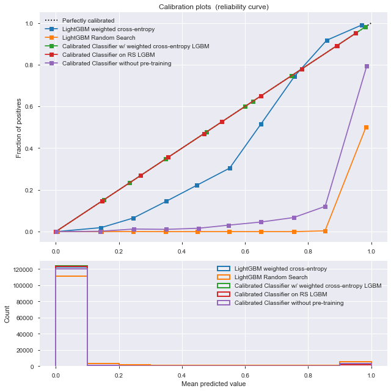

```python
plt.figure(figsize=(9, 9))
ax1 = plt.subplot2grid((3, 1), (0, 0), rowspan=2)
ax2 = plt.subplot2grid((3, 1), (2, 0))

ax1.plot([0, 1], [0, 1], "k:", label="Perfectly calibrated")
for clf, name in [(lgbm, 'LightGBM weighted cross-entropy'),
                  (rs, 'LightGBM Random Search'),
                  (cccv, 'Calibrated Classifier w/ weighted cross-entropy LGBM'),
                  (cccvrs, 'Calibrated Classifier on RS LGBM'),
                  (cccvuntr, 'Calibrated Classifier without pre-training')]:

    if hasattr(clf, "predict_proba"):
        prob_pos = clf.predict_proba(orig_Xtest)[:, 1]
    else:  # use decision function
        prob_pos = clf.decision_function(orig_Xtest)
        prob_pos = \
            (prob_pos - prob_pos.min()) / (prob_pos.max() - prob_pos.min())
    fraction_of_positives, mean_predicted_value = \
        calibration_curve(orig_ytest, prob_pos, n_bins=10)

    ax1.plot(mean_predicted_value, fraction_of_positives, "s-",
             label="%s" % (name, ))

    ax2.hist(prob_pos, range=(0, 1), bins=10, label=name,
             histtype="step", lw=2)

ax1.set_ylabel("Fraction of positives")
ax1.set_ylim([-0.05, 1.05])
ax1.legend(loc="top left")
ax1.set_title('Calibration plots  (reliability curve)')

ax2.set_xlabel("Mean predicted value")
ax2.set_ylabel("Count")
ax2.legend(loc="upper right", ncol=1)

plt.tight_layout()
```

While our most reliable models, Green and Red, do have a lot of False Negatives, which is troubling as we want to *catch* fraud, not miss it, this model demonstrates why model interperetability is so important:

- At proability .5 or above, we always predict fraud, which makes sense because there is a roughly 50% chance of actually being fraud!
- Depending on our business goals though, we can move that threshold down to a number that makes more sense. For example, *if we think that a missed fraud is as bad as bothering three people with a mistaken locked account, we should move this threshold to ~.25* (because 3/4 likelihood no fraud, 1/4 chance of fraud).
- Whatever threshold we choose though, fraud drops off to almost nothing below about ~.15, so we can alert an agent if for the probability, *p*, .15 < *p* < *chosen threshold*.

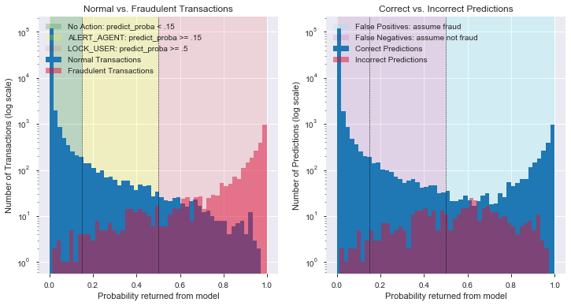

```python
y_pred_cccv = cccv.predict(orig_Xtest)
trues = orig_ytest.astype(int) == y_pred_cccv
y_pred_trues = lgbm.predict_proba(orig_Xtest[trues])
y_pred_errors = lgbm.predict_proba(orig_Xtest[~trues])

frauds = orig_ytest.astype(int) == 1
y_pred_frauds = lgbm.predict_proba(orig_Xtest[frauds])
y_pred_not_frauds = lgbm.predict_proba(orig_Xtest[~frauds])

fig, ax = plt.subplots(nrows=1, ncols=2, figsize=(12,6))
ax[0].axvspan(0, .15, alpha=0.2, facecolor='green', label="No Action: predict_proba < .15")
ax[0].axvspan(.15, .5, facecolor='yellow', alpha=0.2, label="ALERT_AGENT: predict_proba >= .15")
ax[0].axvspan(.5, 1, facecolor='red', alpha=0.1, label="LOCK_USER: predict_proba >= .5")
ax[0].hist(y_pred_not_frauds[:, 1], bins = 50, label="Normal Transactions")
ax[0].hist(y_pred_frauds[:, 1], bins = 50, color = 'crimson', label="Fraudulent Transactions", alpha=.5)
ax[0].axvline(.15, linestyle='dashed', color='k', linewidth=.5)
ax[0].axvline(.5, linestyle='dashed', color='k', linewidth=.5)
ax[0].set_yscale('log')
ax[0].set_ylabel('Number of Transactions (log scale)')
ax[0].set_xlabel('Probability returned from model')
ax[0].set_title('Normal vs. Fraudulent Transactions')
ax[0].legend(loc='upper left')

ax[1].axvspan(0.5, 1, alpha=0.1, facecolor='cyan', label="False Positives: assume fraud")
ax[1].axvspan(0, .5, facecolor='purple', alpha=0.1, label="False Negatives: assume not fraud")
ax[1].hist(y_pred_trues[:, 1], bins = 50, label="Correct Predictions")
ax[1].hist(y_pred_errors[:, 1], bins = 50, color = 'crimson', label="Incorrect Predictions", alpha=.5)
ax[1].axvline(.15, linestyle='dashed', color='k', linewidth=.5)
ax[1].axvline(.5, linestyle='dashed', color='k', linewidth=.5)
ax[1].set_yscale('log')
ax[1].set_ylabel('Number of Predictions (log scale)')
ax[1].set_xlabel('Probability returned from model')
ax[1].set_title('Correct vs. Incorrect Predictions')
ax[1].legend(loc='upper left')

plt.show();
```

Here is what that might look like:

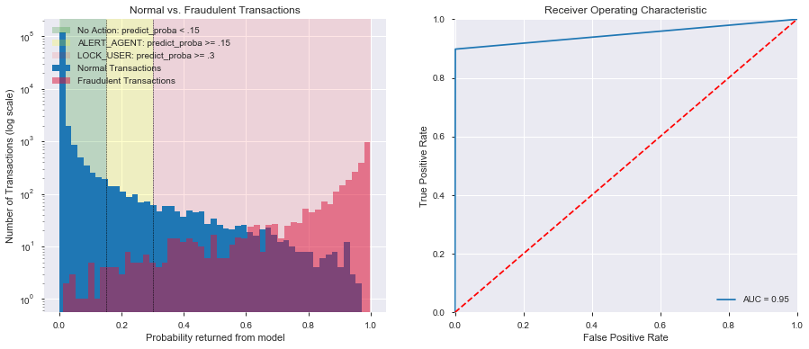

```python
fig, ax = plt.subplots(nrows=1, ncols=2, figsize=(15,6))
ax[0].axvspan(0, .15, alpha=0.2, facecolor='green', label="No Action: predict_proba < .15")
ax[0].axvspan(.15, .3, facecolor='yellow', alpha=0.2, label="ALERT_AGENT: predict_proba >= .15")
ax[0].axvspan(.3, 1, facecolor='red', alpha=0.1, label="LOCK_USER: predict_proba >= .3")
ax[0].hist(y_pred_not_frauds[:, 1], bins = 50, label="Normal Transactions")
ax[0].hist(y_pred_frauds[:, 1], bins = 50, color = 'crimson', label="Fraudulent Transactions", alpha=.5)
ax[0].axvline(.15, linestyle='dashed', color='k', linewidth=.5)
ax[0].axvline(.3, linestyle='dashed', color='k', linewidth=.5)
ax[0].set_yscale('log')
ax[0].set_ylabel('Number of Transactions (log scale)')
ax[0].set_xlabel('Probability returned from model')
ax[0].set_title('Normal vs. Fraudulent Transactions')
ax[0].legend(loc='upper left')

fpr, tpr, thresholds = roc_curve(orig_ytest.astype(int), y_pred_cccv)
roc_auc = auc(fpr, tpr)

ax[1].set_title('Receiver Operating Characteristic')
ax[1].plot(fpr, tpr, label='AUC = %0.2f'% roc_auc)
ax[1].legend(loc='lower right')
ax[1].plot([0,1],[0,1],'r--')
ax[1].set_xlim([-0.001, 1])
ax[1].set_ylim([0, 1.001])
ax[1].set_ylabel('True Positive Rate')
ax[1].set_xlabel('False Positive Rate');
```

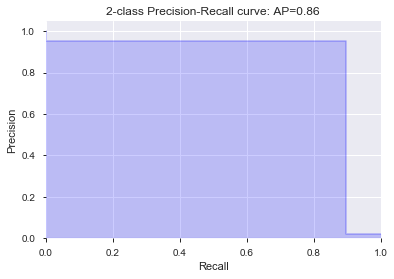

```python
from sklearn.metrics import precision_recall_curve, average_precision_score
import matplotlib.pyplot as plt
from inspect import signature

average_precision = average_precision_score(orig_ytest.astype(int), y_pred_cccv)

precision, recall, _ = precision_recall_curve(orig_ytest.astype(int), y_pred_cccv)

# In matplotlib < 1.5, plt.fill_between does not have a 'step' argument
step_kwargs = ({'step': 'post'}
               if 'step' in signature(plt.fill_between).parameters
               else {})
plt.step(recall, precision, color='b', alpha=0.2,
         where='post')
plt.fill_between(recall, precision, alpha=0.2, color='b', **step_kwargs)

plt.xlabel('Recall')
plt.ylabel('Precision')
plt.ylim([0.0, 1.05])
plt.xlim([0.0, 1.0])
plt.title('2-class Precision-Recall curve: AP={0:0.2f}'.format(
          average_precision));
```

Here we see that more we allow for mistakenly locking an account, the more frauds we will catch!

```python
predict_mine = np.where(cccv.predict_proba(orig_Xtest) > .3, 1, 0)
data1 = confusion_matrix(orig_ytest, predict_mine[:, 1])

predict_mine = np.where(cccv.predict_proba(orig_Xtest) > .18, 1, 0)
data2 = confusion_matrix(orig_ytest, predict_mine[:, 1])
thresholds = [.5, .3, .18]
FPs = [tradeoffs_df.iloc[2, 2], data1[0][1], data2[0][1]]
FNs = [tradeoffs_df.iloc[2, 1], data1[1][0], data2[1][0]]
thresholds_df = pd.DataFrame(list(zip(thresholds, FNs, FPs)),
               columns =['Threshold', '# of FNs (Fraud)', '# of FPs (locked account)'])
thresholds_df
```

|  | Threshold | # of FNs (Fraud) | # of FPs (locked account) |
| --- | --- | --- | --- |
| 0 | 0.50 | 283 | 128 |
| 1 | 0.30 | 176 | 276 |
| 2 | 0.18 | 82 | 583 |

Below you will see the relative feature importances for predicting fraud.

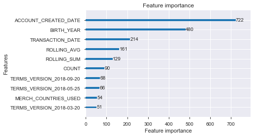

```python
ax = lightgbm.plot_importance(lgbm, max_num_features=10)
plt.show()
```

# Operationalization

How will you utilize this model to catch fraudsters? If a fraudster is identified, what should be the resulting action: LOCK_USER, ALERT_AGENT, or BOTH? Explain. Make a patrol.py file and write a simple function which implements your logic from above. The function should accept a user_id and yield the suggested action(s) (e.g. patrol(user_id) = [‘LOCK_USER’, ‘ALERT_AGENT’])

LOCK_USER - Current transaction is blocked and user’s account is LOCKED. This prevents the user from performing any transactions with their Revolut account. Access can only be restored after contacting an agent.

ALERT_AGENT - Current transaction is not blocked. An alert is sent to a transaction monitoring agent for further review.

# Strategy:

- if a person's maximum predict_proba goes above .15, alert an agent.
- if it goes above .3, lock it.

Since my model has a nearly perfect calibration plot, this means that there is actually over a 30% chance that it was fraudulent. Those numbers could easily be changed given market research, and is as simple as changing a number, but setting it as high as .5 seemed risky. I guess I should get in touch with an agent and see what they think!

```python
user_ids = t.get_user_ids()

# use predict_proba on ALL DATA
y_pred_probas_cccv_train = cccv.predict_proba(orig_Xtrain)
y_pred_probas_cccv_test = cccv.predict_proba(orig_Xtest)

all_preds = pd.concat([pd.DataFrame(y_pred_probas_cccv_train[:,1]), pd.DataFrame(y_pred_probas_cccv_test[:,1])])
join_w_users = all_preds.join(t.get_user_ids())

# max value by user
person_probs = join_w_users.groupby(['USER_ID'], sort=False)[0].max()

# .15 is the cutoff for alerting an agent and .3 we lock it down
above_15_percent = person_probs > .15
above_30_percent = person_probs > .3
ACTION = []
for i in range(len(person_probs)):
    if above_30_percent[i]: ACTION.append('LOCK')
    elif above_15_percent[i]: ACTION.append('ALERT_AGENT')
    else: ACTION.append("NOTHING")

user_action_dict = pd.Series(pd.Series(ACTION).values, index=pd.Series(person_probs.keys())).to_dict()
```

# Next Steps

- K-means to effectively label clusters of users
- Expanding mean target encoding as used in CatBoost for categoricals instead of one-hot-encoding
- Oversampling, GANs to try other class balancing techniques
- Focal Loss is excellent at improving predictive power for class imbalances and a simple improvement. In fact, I already coded it up but didn't have time to implement. :)